# SF City Employee Compensation Part 2

Makena Haroldson

December 3, 2019

### **PREDICTIONS:**

In this project I would like to predict a person’s total benefit based off their job. These predictions may help find the reason why a certain job/organization is more popular than others. From these predictions, we can hopefully make positive changes to help the growth of city jobs.

### **Part 1: Loading Data From Second Source:**

**Step 1: Importing Libraries and Previous Deliverable**

Like we did before, we need to import the data but this time we are taking it from San Francisco City Job’s posting website link. We are using this website as it shows which jobs have an hourly, monthly, or annual income. This information will allow us to compare compensation between hourly and annually paying jobs, as well as, show the increase and decrease of job opening of organization which could effect the popularity of SF city job’s. We also need to download more libraries to be able to do certain functions, as well as connect our first deliverable to this one.

```r
include <- function(library_name){
  if( !(library_name %in% installed.packages()) )
    install.packages(library_name)
  library(library_name, character.only=TRUE)
}

suppressMessages(include("tidyverse"))
suppressMessages(include("knitr"))
suppressMessages(include("rvest"))
suppressMessages(include("tidyr"))
suppressMessages(include("naniar"))
suppressMessages(include("caret"))
suppressMessages(include("varhandle"))
suppressMessages(include("interactions"))

#links our first deliverable here
suppressMessages(purl("deliverable1.Rmd", output = "part1.r"))
```

[output not shown]

```
## [1] "part1.r"
```

```r
suppressMessages(source("part1.r"))

#import website
SFJob_posts_url <- "https://www.jobapscloud.com/SF/"
SFJob_posts_html <- read_html(SFJob_posts_url, options = "HUGE")
```

**Step 2: Importing Website Data Into Tables**

Now we need to read in the website’s data and import it into a table called Job_listing. On the website, rows were labeled as “even” or “odd” so we need to import both and do some maintenance to them. *NOTE: Some job titles have more then one job code in it so we will be using the first one

```r
#Gets each "odd" rows
job_openings_o <- SFJob_posts_html %>%
              html_nodes("tr.odd")
job_title_o <- job_openings_o %>%
              html_nodes("a.JobTitle")%>%
              html_text()
job_dept_o <- job_openings_o %>%
              html_nodes("td.Dept")%>%
              html_text()
job_sal_o <- job_openings_o %>%
              html_nodes("td.Salary") %>%
              html_text()

#Misc. cleaning to import better {

#extracts the front of job title's with multiple job codes
code_clean_index <- job_title_o %>%
              str_which("(^(([0-9]|[A-Z]){4})\\/([0-9]|[A-Z]){4})")

code_replace <- str_extract(job_title_o[code_clean_index], "^([0-9]|[A-Z]){4}")

job_title_o[code_clean_index] <- job_title_o[code_clean_index] %>%
              str_replace("(^(([0-9]|[A-Z]){4})\\/([0-9]|[A-Z]){4})",
              code_replace)

#eliminates the front of title as it blocks job code
code_clean_index <- job_title_o %>%
              str_which("TEX ")
job_title_o[code_clean_index] <- job_title_o[code_clean_index] %>%
              str_replace("TEX ","")
#}

#extracts Job code from the title
job_code_o <- str_extract(job_title_o,"^([0-9]|[A-Z]){4}")

#eliminates Job code from the title
job_title_o <- job_title_o%>%
              str_replace("(^([0-9]|[A-Z]){4} - )|(^([0-9]|[A-Z]){4} )", "")%>%
              str_trim(side = c("right"))

#table of odd rowsc
Job_listing_o <- tibble(Code=job_code_o, Title=job_title_o, Department=job_dept_o, Salary=job_sal_o)
```

We first imported “odd” rows so now we are importing “even” rows. After, we will merge the two together.

```r
#Gets each "even" row
job_openings_e <- SFJob_posts_html %>%
              html_nodes("tr.even")
job_title_e <- job_openings_e %>%
              html_nodes("a.JobTitle")%>%
              html_text()
job_dept_e <- job_openings_e %>%
              html_nodes("td.Dept")%>%
              html_text()
job_sal_e <- job_openings_e %>%
              html_nodes("td.Salary") %>%
              html_text()

#Misc. cleaning to import better {

#extracts the front of job title's with multiple job codes
code_clean_index <- job_title_e %>%
              str_which("(^(([0-9]|[A-Z]){4})\\/([0-9]|[A-Z]){4})")
code_replace <- str_extract(job_title_e[code_clean_index], "^([0-9]|[A-Z]){4}")
job_title_e[code_clean_index] <- job_title_e[code_clean_index] %>%
              str_replace("(^(([0-9]|[A-Z]){4})\\/([0-9]|[A-Z]){4})",
              code_replace)

#eliminates a hyphen in Job code
code_clean_index <- job_title_e %>%
              str_which("^([0-9]|[A-Z]){4}-")
code_replace <- str_extract(job_title_e[code_clean_index], "^([0-9]|[A-Z]){4}")
job_title_e[code_clean_index] <- job_title_e[code_clean_index] %>%
              str_replace("^([0-9]|[A-Z]){4}-",code_replace)

#}

#extracts Job code from the title
job_code_e <- str_extract(job_title_e,"^([0-9]|[A-Z]){4}")

#eliminates Job code from the title
job_title_e <- job_title_e%>%
              str_replace("(^([0-9]|[A-Z]){4} - )|(^([0-9]|[A-Z]){4} )", "")%>%
              str_trim(side = c("right"))

#table of even rows
Job_listing_e <- tibble(Code=job_code_e, Title=job_title_e, Department=job_dept_e, Salary=job_sal_e)


#merge the two tables together
Job_listing <- bind_rows(Job_listing_o,Job_listing_e)

Job_listing
```

```
## # A tibble: 184 x 4
##    Code  Title                   Department          Salary
##    <chr> <chr>                   <chr>               <chr>
##  1 0922  Manager I               "Police "           "$51.59 - $65.85/hour~
##  2 0923  Manager II - Deputy Co~ "Public Utilities ~ "$55.40 - $70.70/hour~
##  3 0923  Manager II, Terminal S~ "Airport - San Fra~ "$55.40 - $70.70/hour~
##  4 0931  Manager III - Manager,~ "Public Health "    "$124,202.00 - $158,5~
##  5 0932  Investment Operations ~ "San Francisco Emp~ "$133,380.00 - $170,2~
##  6 0942  Manager VII, Bureau Ma~ "San Francisco Pub~ "$79.53 - $101.49/hou~
##  7 104X  Applications Engineer ~ "Citywide "         "$91,364.00 - $151,71~
##  8 104X  Security Engineer (All~ "Citywide "         "$91,364.00 - $151,71~
##  9 1052  IS Business Analyst - ~ "Public Utilities ~ "$42.89 - $53.94/hour~
## 10 1054  IS Business Analyst-Pr~ "District Attorney~ "$57.48 - $72.30/hour~
## # ... with 174 more rows
```

### **Part 2: Organizing Data**

Once our table is made we need to organize our Salary column so we can easily use it later on. First we need change some of its values as they are formatted differently than all the other rows. We want the Salary values to have “hour”, “month”, “year”, or nothing at the end of them, instead of “annualized” or other labels. Because this data is coming from a maintained website that will be constantly making updates, it will be hard to catch every single outlier, but these are the few that we did find. *Note: Some job listings have a salary that is bi-weekly, however, we will not adding them into the dataset.

```r
salary_index1 <- Job_listing$Salary %>%
              str_which("ï¿½")
Job_listing$Salary[salary_index1] <- Job_listing$Salary[salary_index1] %>%
              str_replace_all("ï¿½","-")
Job_listing$Salary[salary_index1] <- Job_listing$Salary[salary_index1] %>%
              str_replace("\\/Hour.","\\/hour;")
Job_listing$Salary[salary_index1] <- Job_listing$Salary[salary_index1] %>%
              str_replace("\\/Annual.","00\\/year")

salary_index2 <- Job_listing$Salary %>%
              str_which(" Hourly")
Job_listing$Salary[salary_index2] <- Job_listing$Salary[salary_index2] %>%
              str_replace(" Hourly","/hour")
Job_listing$Salary[salary_index2] <- Job_listing$Salary[salary_index2]%>%
              str_replace(" Annual.","/year")

salary_index3 <- Job_listing$Salary %>%
              str_which("hourly;")
Job_listing$Salary[salary_index3] <- Job_listing$Salary[salary_index3] %>%
              str_replace("hourly;","hour;")
Job_listing$Salary[salary_index3] <- Job_listing$Salary[salary_index3] %>%
              str_replace(" annually ",".00\\/year")

salary_index4 <- Job_listing$Salary %>%
              str_which("\\/hourly")
Job_listing$Salary[salary_index4] <- Job_listing$Salary[salary_index4] %>%
              str_replace("\\/hourly","\\/hour")

salary_index5 <- Job_listing$Salary %>%
              str_which(" per Hour ")
Job_listing$Salary[salary_index5] <- Job_listing$Salary[salary_index5] %>%
              str_replace(" per Hour ","\\/hour")

salary_index6 <- Job_listing$Salary %>%
              str_which("bi-weekly,")
Job_listing$Salary[salary_index6] <- Job_listing$Salary[salary_index6] %>%
              str_replace(", \\$4,631-6,063\\/bi-weekly,","; ;") %>%
              str_replace(" until 12/28/2019 ","")

salary_index7 <- Job_listing$Salary %>%
              str_which("based on")
Job_listing$Salary[salary_index7] <- Job_listing$Salary[salary_index7] %>%
              str_remove(" \\(up to \\$276,484\\.00, based on experience\\/qualifications\\)")

salary_index8 <- Job_listing$Salary %>%
              str_which("Salary Range A;")
Job_listing$Salary[salary_index8] <- Job_listing$Salary[salary_index8] %>%
              str_remove("Salary Range A; ") %>%
              str_replace("hour ","hour; ")%>%
              str_replace("annually ","year")

salary_index9 <- Job_listing$Salary %>%
              str_which("Annualized")
Job_listing$Salary[salary_index9] <- Job_listing$Salary[salary_index9] %>%
              str_remove("\\$2,217 Bi-Weekly; ") %>%
              str_replace("Annualized ","year")


Job_listing
```

```
## # A tibble: 184 x 4
##    Code  Title                   Department          Salary
##    <chr> <chr>                   <chr>               <chr>
##  1 0922  Manager I               "Police "           "$51.59 - $65.85/hour~
##  2 0923  Manager II - Deputy Co~ "Public Utilities ~ "$55.40 - $70.70/hour~
##  3 0923  Manager II, Terminal S~ "Airport - San Fra~ "$55.40 - $70.70/hour~
##  4 0931  Manager III - Manager,~ "Public Health "    "$124,202.00 - $158,5~
##  5 0932  Investment Operations ~ "San Francisco Emp~ "$133,380.00 - $170,2~
##  6 0942  Manager VII, Bureau Ma~ "San Francisco Pub~ "$79.53 - $101.49/hou~
##  7 104X  Applications Engineer ~ "Citywide "         "$91,364.00 - $151,71~
##  8 104X  Security Engineer (All~ "Citywide "         "$91,364.00 - $151,71~
##  9 1052  IS Business Analyst - ~ "Public Utilities ~ "$42.89 - $53.94/hour~
## 10 1054  IS Business Analyst-Pr~ "District Attorney~ "$57.48 - $72.30/hour~
## # ... with 174 more rows
```

Now we need to parse the Salary column out to make a Hr_Salary, Mo_Salary, and Yr_Salary column, but before doing so, we need the Salary column to be formatted the same. After, because they have a range, we will parse these columns out even more to get each individual min and max columns. Some jobs do not have a range and so we will set the value given as a minumum hourly/monthly/annually salary. *NOTE: Some Jobs do not have all three hourly, monthly, and yearly salaries, so we will leave those blank.

```r
#function to put delimiters in rows with
#missing hour, month, or year values
delimiter_placement <- function(index){

  if(!(str_detect(index, "\\/hour") & str_detect(index, "\\/month") & str_detect(index, "\\/year")))
  {
    if(str_detect(index, "\\/hour") & !str_detect(index, "\\/month") & !str_detect(index, "\\/year"))
    {
      #has only a hourly salary
      index <-  paste(index, ";;")

    } else if(!str_detect(index, "\\/hour") & !str_detect(index, "\\/month") & str_detect(index, "\\/year"))
    {
       #has only a yearly salary, append to front
      index <- paste0(";;", index)

    } else if(str_detect(index, "\\/hour") & !str_detect(index, "\\/month") & str_detect(index, "\\/year"))
    {
      #has both hourly and yearly salary
      index <- index %>%
                str_replace("; ",";;")

    } else if(!str_detect(index, "\\/hour") & str_detect(index, "\\/month") & str_detect(index, "\\/year"))
    {
      #has both monthly and yearly salary
      index <- paste0(";", index)

    }
  }
  return(index)
}

suppressWarnings(Job_listing$Salary <- sapply(Job_listing$Salary, delimiter_placement))

suppressWarnings(Job_listing <- Job_listing %>%
              separate(Salary, into = c("Hr_Salary", "Mo_Salary", "Yr_Salary"), sep=";"))

#suppressWarnings about NAs
suppressWarnings(Job_listing <- Job_listing %>% separate(Hr_Salary, into = c("Hr_Salary_Min","Hr_Salary_Max"), sep="-"))
suppressWarnings(Job_listing <- Job_listing %>% separate(Mo_Salary, into = c("Mo_Salary_Min","Mo_Salary_Max"), sep="-"))
suppressWarnings(Job_listing <- Job_listing %>% separate(Yr_Salary, into = c("Yr_Salary_Min","Yr_Salary_Max"), sep="-"))

Job_listing
```

```
## # A tibble: 184 x 9
##    Code  Title Department Hr_Salary_Min Hr_Salary_Max Mo_Salary_Min
##    <chr> <chr> <chr>      <chr>         <chr>         <chr>
##  1 0922  Mana~ "Police "  "$51.59 "     " $65.85/hou~ " $8,942.00 "
##  2 0923  Mana~ "Public U~ "$55.40 "     " $70.70/hou~ " $9,603.00 "
##  3 0923  Mana~ "Airport ~ "$55.40 "     " $70.70/hou~ " $9,603.00 "
##  4 0931  Mana~ "Public H~ ""            <NA>          ""
##  5 0932  Inve~ "San Fran~ ""            <NA>          ""
##  6 0942  Mana~ "San Fran~ "$79.53 "     " $101.49/ho~ " $13,784.00~
##  7 104X  Appl~ "Citywide~ ""            <NA>          ""
##  8 104X  Secu~ "Citywide~ ""            <NA>          ""
##  9 1052  IS B~ "Public U~ "$42.89 "     " $53.94/hou~ " $7,434.00 "
## 10 1054  IS B~ "District~ "$57.48 "     " $72.30/hou~ " $9,962.00 "
## # ... with 174 more rows, and 3 more variables: Mo_Salary_Max <chr>,
## #   Yr_Salary_Min <chr>, Yr_Salary_Max <chr>
```

We want to change these new columns to be of numeric value so we need to elminate characters(ex. “$”, or “hour”) and convert empty values to NA. There was a function made so we can make the same changes to multiple columns easily.

```r
#Convert empty values to NA
Job_listing <- replace_with_na_all(data = Job_listing, condition = ~.x == " ")
Job_listing <- replace_with_na_all(data = Job_listing, condition = ~.x == "")

#function to eliminate characters in each value
char_delete <- function(index2){

  if (!is.na(index2))
  {
    if (str_detect(index2, "\\$"))
    {

      index2 <- index2 %>%
        str_remove("\\$|( \\$)")%>%
        str_trim(side = c("right"))

      #print(index2)

    }
    if(str_detect(index2, "\\/hour"))
    {

      index2 <- index2 %>%
          str_remove("\\/hour")

    }else if(str_detect(index2, "\\/month"))
    {

      index2 <- index2 %>%
          str_remove("\\/month")
    }else if(str_detect(index2, "\\/year"))
    {
      index2 <- index2 %>%
          str_remove("\\/year")
    }
    if (str_detect(index2, ","))
    {
      index2 <- index2 %>%
          str_remove(",")
    }
  }

  return(index2)
}

#sends each Salary column into the function
suppressWarnings(Job_listing$Hr_Salary_Min <- sapply(Job_listing$Hr_Salary_Min, char_delete))
suppressWarnings(Job_listing$Hr_Salary_Max <- sapply(Job_listing$Hr_Salary_Max, char_delete))
suppressWarnings(Job_listing$Mo_Salary_Min <- sapply(Job_listing$Mo_Salary_Min, char_delete))
suppressWarnings(Job_listing$Mo_Salary_Max <- sapply(Job_listing$Mo_Salary_Max, char_delete))
suppressWarnings(Job_listing$Yr_Salary_Min <- sapply(Job_listing$Yr_Salary_Min, char_delete))
suppressWarnings(Job_listing$Yr_Salary_Max <- sapply(Job_listing$Yr_Salary_Max, char_delete))

#turns columns to numeric values
Job_listing$Hr_Salary_Min <- as.numeric(as.character(Job_listing$Hr_Salary_Min))
Job_listing$Hr_Salary_Max <- as.numeric(as.character(Job_listing$Hr_Salary_Max))
Job_listing$Mo_Salary_Min <- as.numeric(as.character(Job_listing$Mo_Salary_Min))
Job_listing$Mo_Salary_Max <- as.numeric(as.character(Job_listing$Mo_Salary_Max))
Job_listing$Yr_Salary_Min <- as.numeric(as.character(Job_listing$Yr_Salary_Min))
Job_listing$Yr_Salary_Max <- as.numeric(as.character(Job_listing$Yr_Salary_Max))

#View(Job_listing)
Job_listing
```

```
## # A tibble: 184 x 9
##    Code  Title Department Hr_Salary_Min Hr_Salary_Max Mo_Salary_Min
##    <chr> <chr> <chr>              <dbl>         <dbl>         <dbl>
##  1 0922  Mana~ "Police "           51.6          65.8          8942
##  2 0923  Mana~ "Public U~          55.4          70.7          9603
##  3 0923  Mana~ "Airport ~          55.4          70.7          9603
##  4 0931  Mana~ "Public H~          NA            NA              NA
##  5 0932  Inve~ "San Fran~          NA            NA              NA
##  6 0942  Mana~ "San Fran~          79.5         101.          13784
##  7 104X  Appl~ "Citywide~          NA            NA              NA
##  8 104X  Secu~ "Citywide~          NA            NA              NA
##  9 1052  IS B~ "Public U~          42.9          53.9          7434
## 10 1054  IS B~ "District~          57.5          72.3          9962
## # ... with 174 more rows, and 3 more variables: Mo_Salary_Max <dbl>,
## #   Yr_Salary_Min <dbl>, Yr_Salary_Max <dbl>
```

We can also easily see the total amount of jobs that are listed per department using a graph.

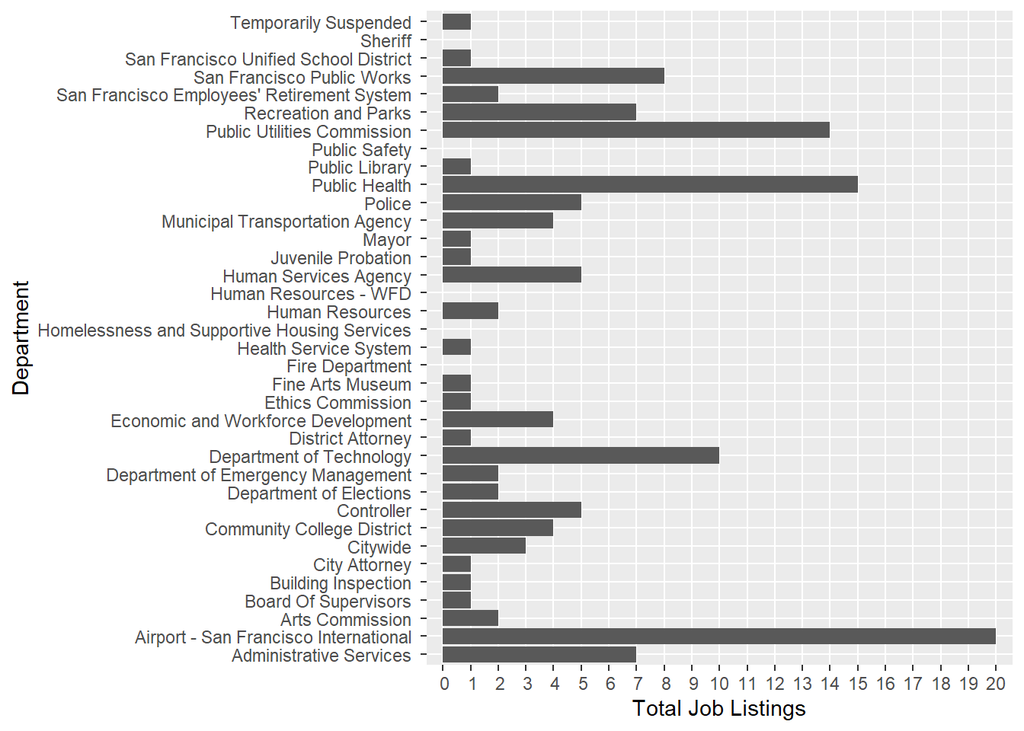

```r
Job_listing$Department <- factor(Job_listing$Department)

Listing_extended <- Job_listing %>%  group_by(Department) %>% summarize(Job_total = n_distinct(Code, na.rm=T))

list_plot <- ggplot(Listing_extended, aes(Department, Job_total)) +  geom_col()+ scale_y_discrete(name = "Total Job Listings", breaks = seq(0, 20, by = 1), limits =seq(0, 20, by = 1))  + coord_flip()

list_plot
```

### **Part 3: Modeling Data**

When looking at our data we just imported, we come across a problem where we cannot trace a particular job to its organization as a job can be in multiple Organization groups. Because of this, we will focus on making a model to see if we can predict the total benefit of each job. First, we need to make a table that have the averages of all the continuous data (ex. Salaries and Other Benefits) from Employee_Earnings. Before we calculate the averages, we need to eliminate the negative values as a person cannot receive a negative salary to find the averages. After, to get the averages we will group each employee by their Job and then calculate the average.

```r
Earnings_filtered <- Employee_Earnings %>%
        filter(Salaries > 0 & !is.nan(Salaries)) %>%
        filter(`Other Salaries` >= 0 & !is.nan(`Other Salaries`)) %>%
        filter(Retirement >= 0 & !is.nan(Retirement)) %>%
        filter(`Health and Dental` >= 0 & !is.nan(`Health and Dental`)) %>%
        filter(`Other Benefits`>= 0 & !is.nan(`Other Benefits`)) %>%
        filter(`Total Benefits`>= 0 & !is.nan(`Total Benefits`)) %>%
        filter(`Total Compensation`> 0 & !is.nan(`Total Compensation`))

#gets the average of a Job's Total Compensation
ave_sal <- aggregate(Salaries ~ `Job Code`, Earnings_filtered, mean)

ave_other_sal <- aggregate(`Other Salaries`  ~ `Job Code`, Earnings_filtered, mean)
#converts value to standard form rather than scientific notation
options(scipen=999)

ave_ret <- aggregate(Retirement ~ `Job Code`, Earnings_filtered, mean)

ave_health <- aggregate(`Health and Dental` ~ `Job Code`, Earnings_filtered, mean)

ave_other_ben <- aggregate(`Other Benefits` ~ `Job Code`, Earnings_filtered, mean)

#gets the average of a Job's Total Benefits
ave_ben <- aggregate(`Total Benefits` ~ `Job Code`, Earnings_filtered, mean)

ave_comp <- aggregate(`Total Compensation` ~ `Job Code`, Earnings_filtered, mean)

Earnings_extended <- full_join(ave_sal, ave_other_sal, by = "Job Code", copy = FALSE )
Earnings_extended <- full_join(ave_ret, Earnings_extended, by = "Job Code", copy = FALSE )
Earnings_extended <- full_join(ave_health, Earnings_extended, by = "Job Code", copy = FALSE )
Earnings_extended <- full_join(ave_other_ben, Earnings_extended, by = "Job Code", copy = FALSE )
Earnings_extended <- full_join(ave_ben, Earnings_extended, by = "Job Code", copy = FALSE )
Earnings_extended <- full_join(ave_comp, Earnings_extended, by = "Job Code", copy = FALSE )

head(Earnings_extended,6)
```

```
##   Job Code Total Compensation Total Benefits Other Benefits
## 1     0109          2187.0343      315.85196      219.30244
## 2     0111           296.2447       61.69777       24.70780
## 3     0112           929.7788      253.71419      162.46609
## 4     0113          1630.9246      200.15538      111.67385
## 5     0114          1408.6714      158.25523       95.77407
## 6     0116         10289.5426      874.15795      724.05551
##   Health and Dental Retirement  Salaries Other Salaries
## 1          83.52729   13.02223 1871.1823              0
## 2          36.68475    0.00000  234.5469              0
## 3          57.73711   32.83634  676.0646              0
## 4          78.44154    0.00000 1430.7692              0
## 5          50.77951   11.33337 1250.4162              0
## 6         150.81372    0.00000 9415.3846              0
```

```r
set.seed(123)

#random picking 70% of the data
sample_selection <- Earnings_extended$`Total Benefits` %>% createDataPartition(p = 0.7, list = FALSE)

train <-Earnings_extended[sample_selection, ]
test <-Earnings_extended[-sample_selection,]

suppressWarnings(train_model <- lm(data=Earnings_extended, formula=`Total Benefits` ~ Salaries + `Other Salaries`+ Retirement + `Health and Dental`+ `Other Benefits` + `Total Compensation`, date = train))

summary(train_model)
```

```
##
## Call:
## lm(formula = `Total Benefits` ~ Salaries + `Other Salaries` +
##     Retirement + `Health and Dental` + `Other Benefits` + `Total Compensation`,
##     data = Earnings_extended, date = train)
##
## Residuals:
##     Min      1Q  Median      3Q     Max
## -1858.1  -259.2   -31.0   150.5 12405.2
##
## Coefficients:
##                         Estimate  Std. Error t value             Pr(>|t|)
## (Intercept)          -128.332486   77.479044  -1.656             0.097918
## Salaries               -0.011969    0.004341  -2.757             0.005923
## `Other Salaries`       -0.026607    0.007753  -3.432             0.000621
## Retirement              0.966764    0.015041  64.276 < 0.0000000000000002
## `Health and Dental`     1.066101    0.009983 106.788 < 0.0000000000000002
## `Other Benefits`        0.979535    0.007407 132.239 < 0.0000000000000002
## `Total Compensation`    0.014790    0.003409   4.338            0.0000156
##
## (Intercept)          .
## Salaries             **
## `Other Salaries`     ***
## Retirement           ***
## `Health and Dental`  ***
## `Other Benefits`     ***
## `Total Compensation` ***
## ---
## Signif. codes:  0 '***' 0.001 '**' 0.01 '*' 0.05 '.' 0.1 ' ' 1
##
## Residual standard error: 705.1 on 1173 degrees of freedom
## Multiple R-squared:  0.997,  Adjusted R-squared:  0.997
## F-statistic: 6.582e+04 on 6 and 1173 DF,  p-value: < 0.00000000000000022
```

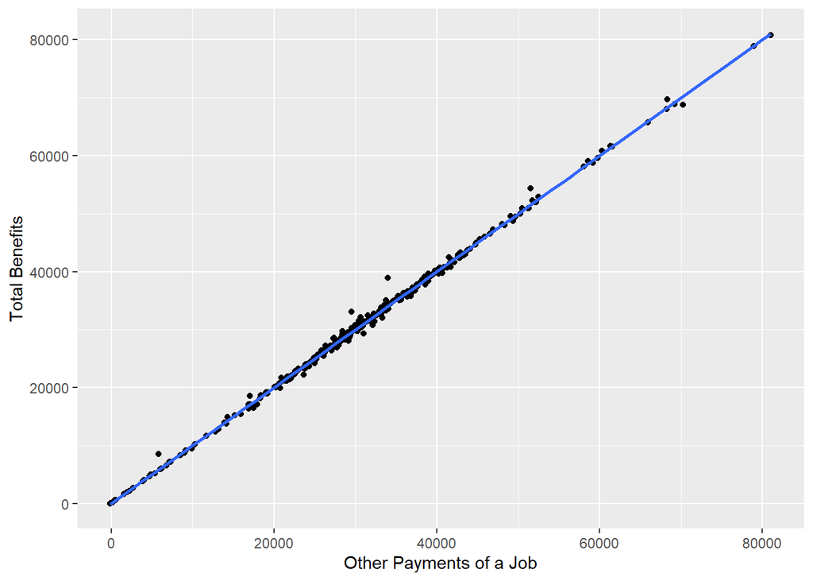

```r
predictions <- train_model %>% predict(test)

#We are trying to predict the total benefits so we will set it as the Y coordinate
ggplot(data = test, aes(x=predictions, y = `Total Benefits`)) + geom_point() + scale_x_continuous(name = "Other Payments of a Job") + geom_smooth(method = "lm")
```

```r
#r^2: how strong the correlation is
#(root it, 1 being stronger correlation)
R2 <- caret::R2(predictions, test$`Total Benefits`)
R2
```

```
## [1] 0.9979748
```

```r
#MAE: Mean absolute error - tells how big an error we can expect
#the smaller the number, the more accurate
MAE <-MAE(predictions, test$`Total Benefits`)
MAE
```

```
## [1] 347.9928
```

**Model Results**